# Explanatory Factor Analysis: What influences love at first sight?

### Rotation 1

Let’s try to use the maximum number of factors.

#### [1] No rotation

```r
fa(dating12, nfactors=15, rotate="none", fm="ml")
```

```
## Factor Analysis using method =  ml
## Call: fa(r = dating12, nfactors = 15, rotate = "none", fm = "ml")
## Standardized loadings (pattern matrix) based upon correlation matrix
##            ML1  ML11   ML2  ML10  ML12  ML13   ML3   ML4  ML14   ML8  ML15
## imprace  -0.06 -0.01  0.00  0.14  0.18 -0.10  0.01  0.08  0.26  0.01 -0.08
## imprelig -0.01 -0.09  0.17  0.04  0.11 -0.02  0.09  0.11  0.19 -0.02  0.02
## date      0.02 -0.09  0.23 -0.03 -0.05 -0.13  0.04 -0.06 -0.07  0.05 -0.20
## go_out    0.05  0.03  0.12 -0.01 -0.07 -0.18  0.05 -0.15 -0.04 -0.08 -0.20
## sports    0.05 -0.04 -0.23 -0.03  0.17  0.72 -0.01 -0.07  0.22  0.08 -0.27
## tvsports  0.08 -0.01 -0.16  0.05  0.36  0.29  0.10 -0.14  0.29  0.13 -0.27
## exercise -0.11 -0.04 -0.06  0.12  0.11  0.37 -0.03  0.04  0.24  0.04 -0.07
## dining   -0.08  0.29  0.07  0.28  0.14  0.02 -0.02  0.10  0.11 -0.04  0.24
## museums  -0.06  0.83  0.16  0.33 -0.16  0.00  0.04  0.07  0.10 -0.12 -0.04
## art      -0.07  0.77  0.12  0.34 -0.12  0.00  0.05  0.07  0.02 -0.06 -0.01
## hiking    0.07  0.21  0.07  0.08 -0.05  0.27 -0.05 -0.04 -0.11  0.07 -0.09
## gaming    0.14  0.01 -0.14  0.06  0.28  0.01 -0.01 -0.03  0.06  0.00 -0.07
## clubbing -0.05  0.08 -0.06  0.19  0.11  0.08 -0.05 -0.02 -0.01  0.05  0.07
## reading   0.00  0.24  0.14  0.04 -0.09 -0.03  0.00  0.07  0.03 -0.13  0.11
## tv        0.04  0.01  0.11  0.15  0.58 -0.42  0.05 -0.03  0.44  0.08 -0.12
## theater  -0.06  0.44  0.26  0.32  0.17 -0.20  0.00  0.05 -0.03 -0.05  0.01
## movies    0.01  0.30  0.15  0.17  0.37 -0.22  0.01 -0.02 -0.04 -0.03 -0.02
## concerts -0.03  0.46  0.10  0.20  0.49  0.09  0.09  0.01 -0.52  0.02 -0.05
## music    -0.02  0.33  0.05  0.18  0.45  0.11  0.04  0.02 -0.38  0.08  0.10
## shopping -0.16  0.14  0.08  0.34  0.38 -0.20 -0.02  0.02  0.21  0.07  0.10
## yoga     -0.02  0.23  0.11  0.17  0.08  0.08  0.05  0.05 -0.07  0.07  0.11
## exphappy  0.13  0.13 -0.16 -0.01  0.15  0.20 -0.07 -0.02  0.01  0.04  0.02
## attr1_1  -0.58  0.03 -0.65 -0.04  0.00 -0.01 -0.03 -0.15  0.00 -0.04  0.00
## sinc1_1   0.36  0.02  0.53 -0.04  0.00  0.00 -0.07 -0.68  0.00  0.01  0.00
## intel1_1 -0.03  0.06  0.12 -0.31  0.03  0.01 -0.07  0.18  0.01 -0.61  0.01
## fun1_1    0.08  0.11 -0.08 -0.24  0.00  0.00 -0.39  0.19  0.00  0.73  0.00
## amb1_1    0.23 -0.30  0.22  0.77 -0.05  0.01  0.02  0.21 -0.03  0.02 -0.02
## shar1_1   0.43  0.02  0.40 -0.04  0.00  0.00  0.56  0.47  0.00  0.01  0.00
## attr2_1  -0.91  0.01  0.22  0.02  0.00  0.00  0.24 -0.11  0.00  0.02  0.00
## sinc2_1   0.69  0.01 -0.10  0.01  0.00  0.00  0.01 -0.33  0.00 -0.05  0.00
## intel2_1  0.56  0.00 -0.45  0.02  0.00  0.00 -0.18  0.05  0.00  0.04  0.00
## fun2_1    0.03  0.01  0.32  0.01  0.00  0.00 -0.83  0.34  0.00 -0.08  0.00
## amb2_1    0.50  0.02 -0.51  0.00  0.00  0.00  0.20  0.05  0.00 -0.05  0.00
## shar2_1   0.43 -0.02  0.22 -0.09  0.01 -0.01  0.20  0.16  0.00  0.11 -0.01
## attr3_1  -0.07  0.05 -0.21  0.20  0.10  0.25 -0.05  0.04  0.20  0.00  0.46
## sinc3_1   0.09  0.10  0.22  0.08  0.15  0.15  0.02 -0.20  0.12  0.02  0.25
```

[output cut: 71 more lines]

```
## BIC =  9096.62
## Fit based upon off diagonal values = 0.95
## Measures of factor score adequacy
##                                                   ML1 ML11  ML2 ML10 ML12 ML13
## Correlation of (regression) scores with factors     1 0.97 1.00 0.98 0.92 0.90
## Multiple R square of scores with factors            1 0.95 1.00 0.96 0.84 0.81
## Minimum correlation of possible factor scores       1 0.90 0.99 0.92 0.68 0.62
##                                                    ML3  ML4 ML14  ML8 ML15  ML5
## Correlation of (regression) scores with factors   1.00 1.00 0.89 0.99 0.83 1.00
## Multiple R square of scores with factors          1.00 0.99 0.79 0.98 0.69 0.99
## Minimum correlation of possible factor scores     0.99 0.99 0.58 0.96 0.38 0.99
##                                                    ML7  ML9  ML6
## Correlation of (regression) scores with factors   0.99 0.99 1.00
## Multiple R square of scores with factors          0.99 0.97 0.99
## Minimum correlation of possible factor scores     0.98 0.95 0.99
```

Too many factors. It is extremely difficult to interpret such a result.

Let’s try to reduce the number of factors.

#### [2] No rotation

```r
fa(dating12, nfactors=5, rotate="none", fm="ml")
```

```
## Factor Analysis using method =  ml
## Call: fa(r = dating12, nfactors = 5, rotate = "none", fm = "ml")
## Standardized loadings (pattern matrix) based upon correlation matrix
##            ML3   ML4   ML2   ML1   ML5    h2     u2 com
## imprace   0.06  0.09 -0.04 -0.03  0.24 0.073 0.9269 1.5
## imprelig  0.01 -0.05 -0.04 -0.05  0.30 0.096 0.9041 1.2
## date     -0.06 -0.35 -0.06 -0.01  0.08 0.138 0.8619 1.2
## go_out    0.02 -0.31  0.01 -0.03 -0.03 0.097 0.9033 1.0
## sports   -0.14  0.40  0.14  0.04 -0.12 0.214 0.7857 1.7
## tvsports -0.07  0.29  0.19 -0.07  0.11 0.143 0.8566 2.3
## exercise  0.00  0.31 -0.07 -0.03  0.06 0.105 0.8951 1.2
## dining    0.41  0.25 -0.10 -0.02  0.21 0.292 0.7077 2.4
## museums   0.91 -0.04 -0.09 -0.06 -0.13 0.853 0.1467 1.1
## art       0.90  0.01 -0.08 -0.07 -0.15 0.843 0.1574 1.1
## hiking    0.21  0.03  0.01  0.07 -0.09 0.060 0.9401 1.7
## gaming   -0.02  0.21  0.14  0.09  0.11 0.085 0.9146 2.8
## clubbing  0.12  0.26 -0.04 -0.01  0.08 0.091 0.9089 1.7
## reading   0.30 -0.13 -0.06  0.01 -0.01 0.108 0.8917 1.5
## tv        0.09  0.06  0.00 -0.02  0.50 0.262 0.7383 1.1
## theater   0.61 -0.09 -0.14 -0.04  0.29 0.482 0.5176 1.6
## movies    0.38 -0.04 -0.04 -0.02  0.32 0.252 0.7481 2.0
## concerts  0.45  0.06 -0.02 -0.08  0.16 0.233 0.7671 1.4
## music     0.32  0.18 -0.02 -0.03  0.19 0.171 0.8292 2.3
## shopping  0.28  0.26 -0.16 -0.09  0.42 0.353 0.6467 3.0
## yoga      0.32  0.08 -0.03 -0.05  0.12 0.127 0.8726 1.5
## exphappy  0.07  0.26  0.13  0.12 -0.05 0.109 0.8912 2.2
## attr1_1  -0.21  0.47 -0.14 -0.31 -0.42 0.555 0.4454 3.4
## sinc1_1   0.02 -0.37  0.09  0.12  0.19 0.196 0.8040 1.9
## intel1_1  0.12 -0.26 -0.08 -0.04 -0.02 0.089 0.9106 1.7
## fun1_1   -0.05  0.15 -0.10  0.28 -0.04 0.114 0.8858 2.0
## amb1_1    0.18 -0.04  0.05  0.16  0.42 0.239 0.7606 1.7
## shar1_1   0.10 -0.31  0.26  0.09  0.24 0.245 0.7552 3.3
## attr2_1  -0.01  0.00 -0.61 -0.79  0.00 0.995 0.0049 1.9
## sinc2_1  -0.02 -0.02  0.57  0.36 -0.01 0.452 0.5481 1.7
## intel2_1 -0.01  0.10  0.52  0.32 -0.07 0.391 0.6086 1.8
## fun2_1    0.00  0.00 -0.63  0.77  0.00 0.995 0.0050 1.9
## amb2_1   -0.07  0.10  0.59  0.21 -0.11 0.419 0.5811 1.4
## shar2_1   0.15 -0.19  0.41  0.26  0.21 0.342 0.6576 3.1
## attr3_1   0.12  0.53  0.04  0.01  0.06 0.302 0.6978 1.2
## sinc3_1   0.14  0.03  0.02  0.00  0.25 0.087 0.9133 1.6
```

[output cut: 17 more lines]

```
## The root mean square of the residuals (RMSR) is  0.07
## The df corrected root mean square of the residuals is  0.08
##
## The harmonic n.obs is  8191 with the empirical chi square  56272.09  with prob <  0
## The total n.obs was  8191  with Likelihood Chi Square =  80980.15  with prob <  0
##
## Tucker Lewis Index of factoring reliability =  0.251
## RMSEA index =  0.133  and the 90 % confidence intervals are  0.132 0.134
## BIC =  75970.16
## Fit based upon off diagonal values = 0.77
## Measures of factor score adequacy
##                                                    ML3  ML4  ML2  ML1  ML5
## Correlation of (regression) scores with factors   0.96 0.88 1.00 1.00 0.85
## Multiple R square of scores with factors          0.93 0.78 0.99 1.00 0.73
## Minimum correlation of possible factor scores     0.86 0.56 0.99 0.99 0.45
```

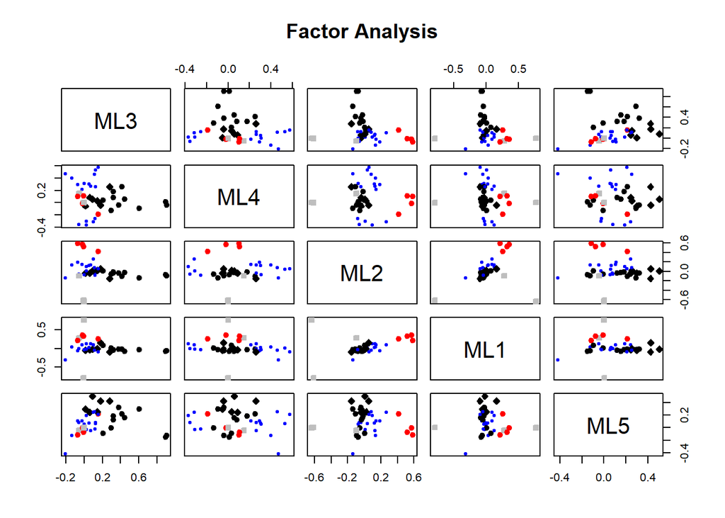

```r
factor.plot(fa(dating12, nfactors=5, rotate="none", fm="ml"))
```

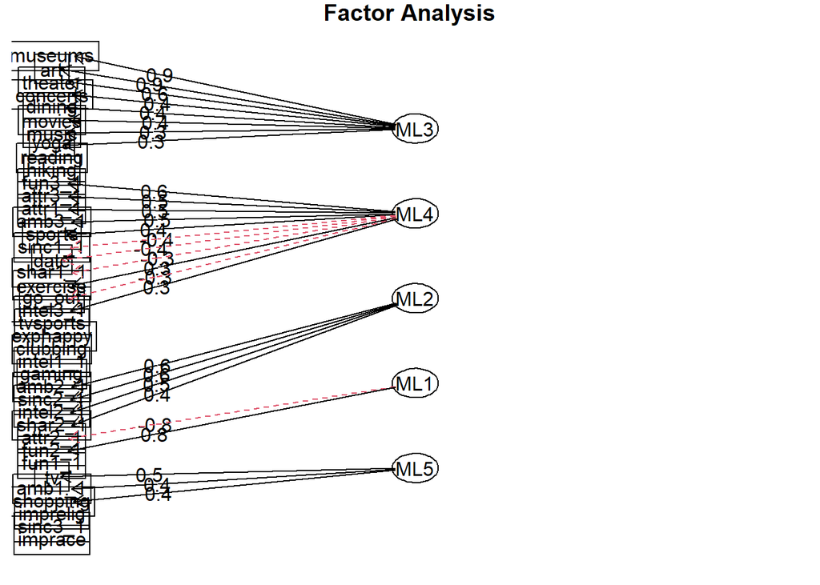

```r
fa.diagram(fa(dating12, nfactors=5, rotate="none", fm="ml"))
```

Try to use a rotation. Compare the results.

#### [3] rotation varimax

```r
fa(dating12, nfactors=5, rotate="varimax", fm="ml")
```

```
## Factor Analysis using method =  ml
## Call: fa(r = dating12, nfactors = 5, rotate = "varimax", fm = "ml")
## Standardized loadings (pattern matrix) based upon correlation matrix
##            ML3   ML2   ML4   ML5   ML1    h2     u2 com
## imprace   0.03 -0.05  0.09  0.25  0.00 0.073 0.9269 1.4
## imprelig -0.03 -0.05 -0.04  0.30 -0.04 0.096 0.9041 1.2
## date     -0.07 -0.03 -0.35  0.09 -0.02 0.138 0.8619 1.2
## go_out    0.02  0.02 -0.30 -0.01 -0.06 0.097 0.9033 1.1
## sports   -0.13  0.09  0.41 -0.16  0.01 0.214 0.7857 1.6
## tvsports -0.10  0.09  0.32  0.08 -0.13 0.143 0.8566 1.8
## exercise  0.00 -0.10  0.30  0.05  0.04 0.105 0.8951 1.3
## dining    0.39 -0.08  0.25  0.26  0.04 0.292 0.7077 2.7
## museums   0.92 -0.04 -0.04  0.00 -0.04 0.853 0.1467 1.0
## art       0.92 -0.04  0.01 -0.03 -0.05 0.843 0.1574 1.0
## hiking    0.22  0.06  0.03 -0.07  0.06 0.060 0.9401 1.5
## gaming   -0.05  0.15  0.23  0.09  0.02 0.085 0.9146 2.2
## clubbing  0.12 -0.05  0.26  0.09  0.03 0.091 0.9089 1.8
## reading   0.30 -0.01 -0.14  0.04  0.02 0.108 0.8917 1.5
## tv        0.02  0.01  0.08  0.50 -0.03 0.262 0.7383 1.1
## theater   0.57 -0.08 -0.09  0.37  0.00 0.482 0.5176 1.8
## movies    0.34  0.00 -0.03  0.37 -0.02 0.252 0.7481 2.0
## concerts  0.42 -0.03  0.07  0.21 -0.07 0.233 0.7671 1.6
## music     0.30 -0.02  0.19  0.22 -0.02 0.171 0.8292 2.6
## shopping  0.24 -0.17  0.26  0.45  0.01 0.353 0.6467 2.5
## yoga      0.30 -0.03  0.09  0.16 -0.03 0.127 0.8726 1.8
## exphappy  0.07  0.16  0.27 -0.05  0.06 0.109 0.8912 1.9
## attr1_1  -0.13 -0.35  0.44 -0.45 -0.12 0.555 0.4454 3.2
## sinc1_1  -0.01  0.18 -0.35  0.20  0.01 0.196 0.8040 2.2
## intel1_1  0.13 -0.06 -0.26  0.01 -0.02 0.089 0.9106 1.6
## fun1_1   -0.04  0.06  0.12 -0.05  0.30 0.114 0.8858 1.5
## amb1_1    0.11  0.16 -0.02  0.44  0.08 0.239 0.7606 1.5
## shar1_1   0.04  0.31 -0.27  0.25 -0.11 0.245 0.7552 3.3
## attr2_1   0.05 -0.94 -0.05  0.02 -0.32 0.995 0.0049 1.2
## sinc2_1  -0.07  0.67  0.04 -0.03 -0.01 0.452 0.5481 1.0
## intel2_1 -0.04  0.60  0.15 -0.10  0.00 0.391 0.6086 1.2
## fun2_1    0.04 -0.10 -0.11  0.04  0.99 0.995 0.0050 1.1
## amb2_1   -0.10  0.59  0.16 -0.15 -0.13 0.419 0.5811 1.5
## shar2_1   0.09  0.52 -0.14  0.22 -0.04 0.342 0.6576 1.6
## attr3_1   0.11  0.01  0.53  0.06  0.04 0.302 0.6978 1.1
## sinc3_1   0.11  0.03  0.05  0.27 -0.02 0.087 0.9133 1.4
```

[output cut: 17 more lines]

```
## The root mean square of the residuals (RMSR) is  0.07
## The df corrected root mean square of the residuals is  0.08
##
## The harmonic n.obs is  8191 with the empirical chi square  56272.09  with prob <  0
## The total n.obs was  8191  with Likelihood Chi Square =  80980.15  with prob <  0
##
## Tucker Lewis Index of factoring reliability =  0.251
## RMSEA index =  0.133  and the 90 % confidence intervals are  0.132 0.134
## BIC =  75970.16
## Fit based upon off diagonal values = 0.77
## Measures of factor score adequacy
##                                                    ML3  ML2  ML4  ML5  ML1
## Correlation of (regression) scores with factors   0.96 1.00 0.88 0.85 1.00
## Multiple R square of scores with factors          0.93 0.99 0.78 0.73 0.99
## Minimum correlation of possible factor scores     0.85 0.98 0.57 0.46 0.99
```

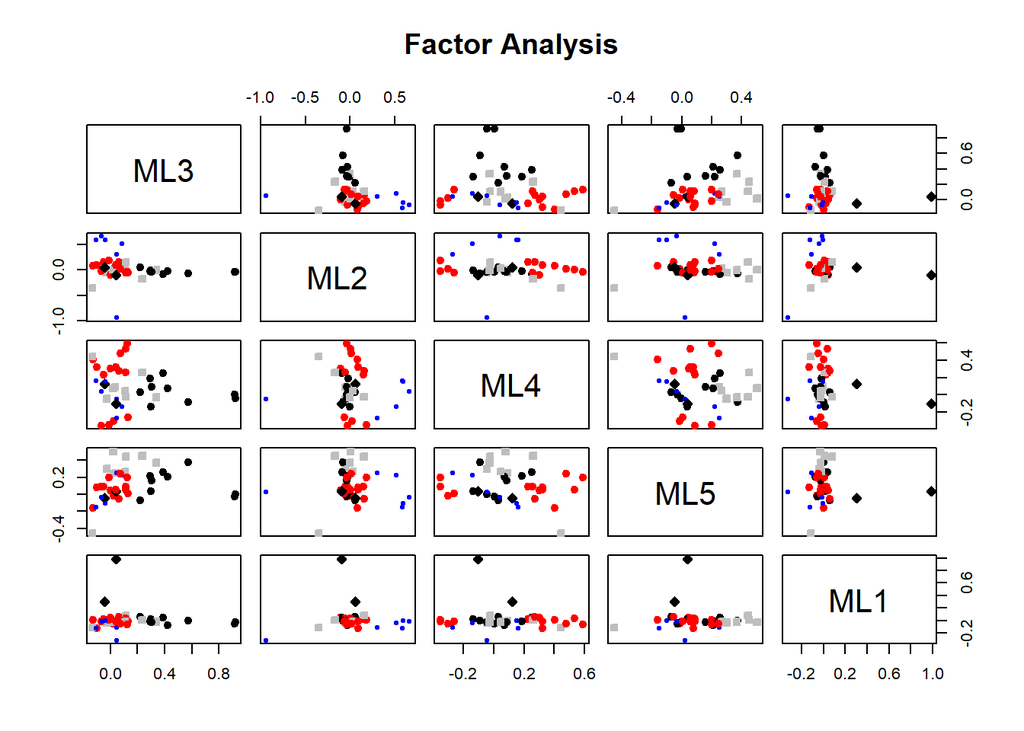

```r
factor.plot(fa(dating12, nfactors=5, rotate="varimax", fm="ml"))
```

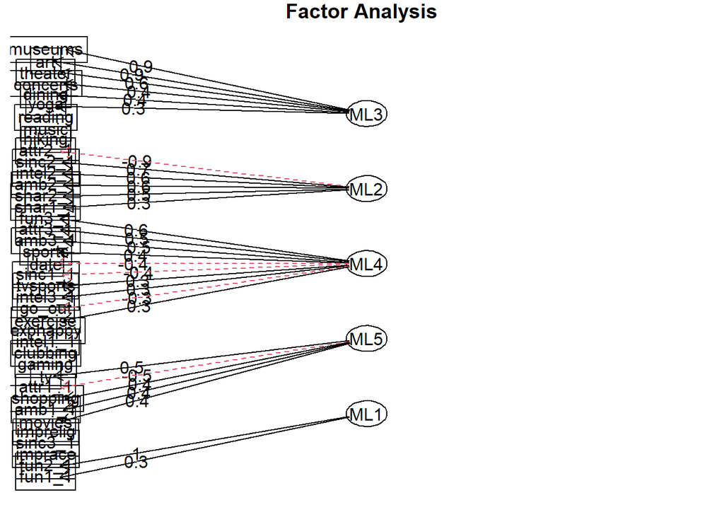

```r
fa.diagram(fa(dating12, nfactors=5, rotate="varimax", fm="ml"))
```

The same result, so the factors are related. Try another rotation - oblique (oblimin)

#### [4] rotation oblimin

```r
fa(dating12, nfactors=5, rotate="oblimin", fm="ml")
```

```
## Factor Analysis using method =  ml
## Call: fa(r = dating12, nfactors = 5, rotate = "oblimin", fm = "ml")
## Standardized loadings (pattern matrix) based upon correlation matrix
##            ML3   ML2   ML4   ML5   ML1    h2     u2 com
## imprace  -0.05 -0.08  0.21  0.18  0.01 0.073 0.9269 2.4
## imprelig -0.12 -0.12  0.11  0.29 -0.03 0.096 0.9041 2.0
## date     -0.07 -0.11 -0.27  0.23 -0.01 0.138 0.8619 2.5
## go_out    0.05 -0.03 -0.28  0.13 -0.06 0.097 0.9033 1.6
## sports   -0.10  0.18  0.27 -0.31 -0.02 0.214 0.7857 2.9
## tvsports -0.13  0.11  0.31 -0.04 -0.15 0.143 0.8566 2.2
## exercise -0.04 -0.05  0.30 -0.10  0.06 0.105 0.8951 1.4
## dining    0.29 -0.06  0.37  0.11  0.06 0.292 0.7077 2.2
## museums   0.93  0.01 -0.03 -0.01  0.00 0.853 0.1467 1.0
## art       0.93  0.01  0.00 -0.06 -0.02 0.843 0.1574 1.0
## hiking    0.24  0.09  0.00 -0.08  0.05 0.060 0.9401 1.6
## gaming   -0.08  0.17  0.24  0.00 -0.01 0.085 0.9146 2.1
## clubbing  0.07 -0.01  0.28 -0.05  0.04 0.091 0.9089 1.2
## reading   0.29 -0.02 -0.10  0.09  0.03 0.108 0.8917 1.4
## tv       -0.14 -0.08  0.32  0.44 -0.03 0.262 0.7383 2.1
## theater   0.46 -0.13  0.12  0.36  0.04 0.482 0.5176 2.2
## movies    0.23 -0.06  0.16  0.35 -0.01 0.252 0.7481 2.3
## concerts  0.36 -0.04  0.17  0.15 -0.05 0.233 0.7671 1.9
## music     0.22 -0.01  0.28  0.11 -0.01 0.171 0.8292 2.3
## shopping  0.07 -0.19  0.47  0.27  0.05 0.353 0.6467 2.1
## yoga      0.25 -0.03  0.16  0.10 -0.01 0.127 0.8726 2.1
## exphappy  0.07  0.22  0.21 -0.15  0.03 0.109 0.8912 3.0
## attr1_1  -0.04 -0.20  0.17 -0.65 -0.07 0.555 0.4454 1.4
## sinc1_1  -0.04  0.08 -0.22  0.36 -0.02 0.196 0.8040 1.8
## intel1_1  0.14 -0.10 -0.23  0.11 -0.01 0.089 0.9106 2.7
## fun1_1   -0.05  0.13  0.10 -0.11  0.29 0.114 0.8858 2.1
## amb1_1   -0.01  0.08  0.20  0.43  0.06 0.239 0.7606 1.5
## shar1_1   0.01  0.19 -0.13  0.40 -0.16 0.245 0.7552 2.0
## attr2_1   0.00 -0.97 -0.01 -0.07 -0.16 0.995 0.0049 1.1
## sinc2_1  -0.02  0.66 -0.01  0.05 -0.13 0.452 0.5481 1.1
## intel2_1  0.01  0.62  0.06 -0.08 -0.11 0.391 0.6086 1.1
## fun2_1   -0.01  0.02 -0.01 -0.01  1.00 0.995 0.0050 1.0
## amb2_1   -0.03  0.60  0.03 -0.12 -0.23 0.419 0.5811 1.4
## shar2_1   0.06  0.43 -0.04  0.34 -0.12 0.342 0.6576 2.1
## attr3_1   0.06  0.10  0.51 -0.19  0.03 0.302 0.6978 1.4
## sinc3_1   0.03 -0.01  0.17  0.23 -0.02 0.087 0.9133 1.9
```

[output cut: 25 more lines]

```
## The root mean square of the residuals (RMSR) is  0.07
## The df corrected root mean square of the residuals is  0.08
##
## The harmonic n.obs is  8191 with the empirical chi square  56272.09  with prob <  0
## The total n.obs was  8191  with Likelihood Chi Square =  80980.15  with prob <  0
##
## Tucker Lewis Index of factoring reliability =  0.251
## RMSEA index =  0.133  and the 90 % confidence intervals are  0.132 0.134
## BIC =  75970.16
## Fit based upon off diagonal values = 0.77
## Measures of factor score adequacy
##                                                    ML3  ML2  ML4  ML5  ML1
## Correlation of (regression) scores with factors   0.96 1.00 0.88 0.88 1.00
## Multiple R square of scores with factors          0.93 0.99 0.78 0.77 0.99
## Minimum correlation of possible factor scores     0.85 0.99 0.56 0.54 0.99
```

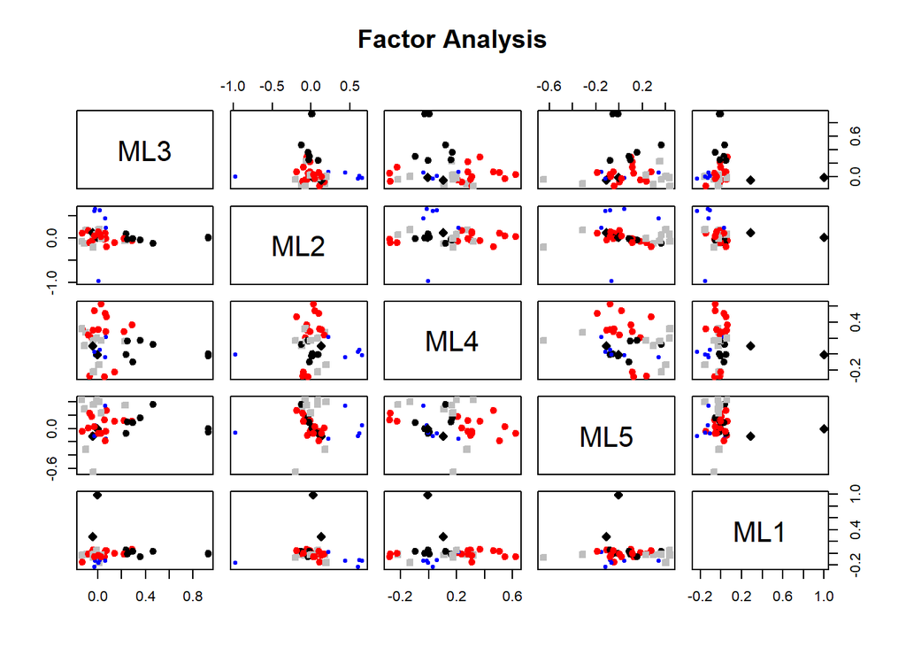

```r
factor.plot(fa(dating12, nfactors=5, rotate="oblimin", fm="ml"))
```

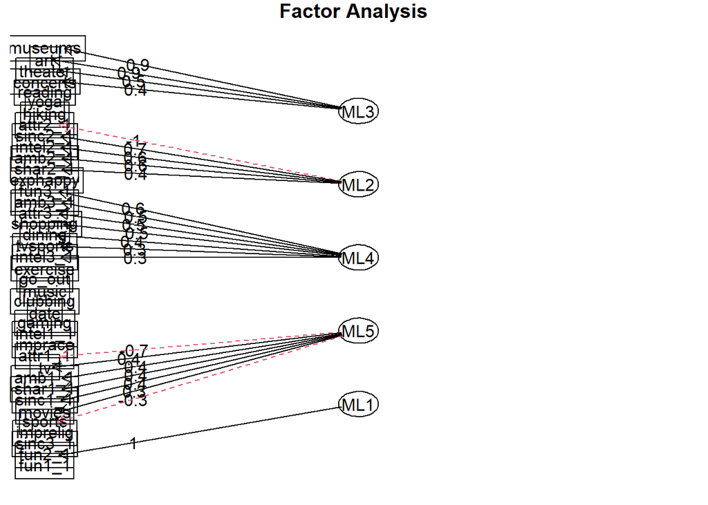

```r
fa.diagram(fa(dating12, nfactors=5, rotate="oblimin", fm="ml"))
```

The result is the same, so we need to exclude variables to improve the EFA

## Part 2. Improving The Model

### Exluding the variables 1.

Communality is the sum of squared factor loadings for the variables, so to exclude variables we are looking at this parameter (if variable do not belong to either of the factors, this factor should not be presented). Factor loadings have to be 0.4 or more to be acceptable. That means that a threshold for communality of the variable should be 0.16

```r
oblfa = fa(dating12, nfactors=5, rotate="oblimin", fm="ml")
oblfa
```

```
## Factor Analysis using method =  ml
## Call: fa(r = dating12, nfactors = 5, rotate = "oblimin", fm = "ml")
## Standardized loadings (pattern matrix) based upon correlation matrix
##            ML3   ML2   ML4   ML5   ML1    h2     u2 com
## imprace  -0.05 -0.08  0.21  0.18  0.01 0.073 0.9269 2.4
## imprelig -0.12 -0.12  0.11  0.29 -0.03 0.096 0.9041 2.0
## date     -0.07 -0.11 -0.27  0.23 -0.01 0.138 0.8619 2.5
## go_out    0.05 -0.03 -0.28  0.13 -0.06 0.097 0.9033 1.6
## sports   -0.10  0.18  0.27 -0.31 -0.02 0.214 0.7857 2.9
## tvsports -0.13  0.11  0.31 -0.04 -0.15 0.143 0.8566 2.2
## exercise -0.04 -0.05  0.30 -0.10  0.06 0.105 0.8951 1.4
## dining    0.29 -0.06  0.37  0.11  0.06 0.292 0.7077 2.2
## museums   0.93  0.01 -0.03 -0.01  0.00 0.853 0.1467 1.0
## art       0.93  0.01  0.00 -0.06 -0.02 0.843 0.1574 1.0
## hiking    0.24  0.09  0.00 -0.08  0.05 0.060 0.9401 1.6
## gaming   -0.08  0.17  0.24  0.00 -0.01 0.085 0.9146 2.1
## clubbing  0.07 -0.01  0.28 -0.05  0.04 0.091 0.9089 1.2
## reading   0.29 -0.02 -0.10  0.09  0.03 0.108 0.8917 1.4
## tv       -0.14 -0.08  0.32  0.44 -0.03 0.262 0.7383 2.1
## theater   0.46 -0.13  0.12  0.36  0.04 0.482 0.5176 2.2
## movies    0.23 -0.06  0.16  0.35 -0.01 0.252 0.7481 2.3
## concerts  0.36 -0.04  0.17  0.15 -0.05 0.233 0.7671 1.9
## music     0.22 -0.01  0.28  0.11 -0.01 0.171 0.8292 2.3
## shopping  0.07 -0.19  0.47  0.27  0.05 0.353 0.6467 2.1
## yoga      0.25 -0.03  0.16  0.10 -0.01 0.127 0.8726 2.1
## exphappy  0.07  0.22  0.21 -0.15  0.03 0.109 0.8912 3.0
## attr1_1  -0.04 -0.20  0.17 -0.65 -0.07 0.555 0.4454 1.4
## sinc1_1  -0.04  0.08 -0.22  0.36 -0.02 0.196 0.8040 1.8
## intel1_1  0.14 -0.10 -0.23  0.11 -0.01 0.089 0.9106 2.7
## fun1_1   -0.05  0.13  0.10 -0.11  0.29 0.114 0.8858 2.1
## amb1_1   -0.01  0.08  0.20  0.43  0.06 0.239 0.7606 1.5
## shar1_1   0.01  0.19 -0.13  0.40 -0.16 0.245 0.7552 2.0
## attr2_1   0.00 -0.97 -0.01 -0.07 -0.16 0.995 0.0049 1.1
## sinc2_1  -0.02  0.66 -0.01  0.05 -0.13 0.452 0.5481 1.1
## intel2_1  0.01  0.62  0.06 -0.08 -0.11 0.391 0.6086 1.1
## fun2_1   -0.01  0.02 -0.01 -0.01  1.00 0.995 0.0050 1.0
## amb2_1   -0.03  0.60  0.03 -0.12 -0.23 0.419 0.5811 1.4
## shar2_1   0.06  0.43 -0.04  0.34 -0.12 0.342 0.6576 2.1
## attr3_1   0.06  0.10  0.51 -0.19  0.03 0.302 0.6978 1.4
## sinc3_1   0.03 -0.01  0.17  0.23 -0.02 0.087 0.9133 1.9
```

[output cut: 25 more lines]

```
## The root mean square of the residuals (RMSR) is  0.07
## The df corrected root mean square of the residuals is  0.08
##
## The harmonic n.obs is  8191 with the empirical chi square  56272.09  with prob <  0
## The total n.obs was  8191  with Likelihood Chi Square =  80980.15  with prob <  0
##
## Tucker Lewis Index of factoring reliability =  0.251
## RMSEA index =  0.133  and the 90 % confidence intervals are  0.132 0.134
## BIC =  75970.16
## Fit based upon off diagonal values = 0.77
## Measures of factor score adequacy
##                                                    ML3  ML2  ML4  ML5  ML1
## Correlation of (regression) scores with factors   0.96 1.00 0.88 0.88 1.00
## Multiple R square of scores with factors          0.93 0.99 0.78 0.77 0.99
## Minimum correlation of possible factor scores     0.85 0.99 0.56 0.54 0.99
```

```r
com = data.frame(oblfa$communality)
library(dplyr)
arrange(com, oblfa.communality)
```

```
##          oblfa.communality
## hiking          0.05986141
## imprace         0.07306658
## gaming          0.08543416
## sinc3_1         0.08671057
## intel1_1        0.08938205
## clubbing        0.09112199
## imprelig        0.09589925
## go_out          0.09666240
## exercise        0.10489908
## reading         0.10834963
## exphappy        0.10880022
## fun1_1          0.11417838
## intel3_1        0.11653218
## yoga            0.12736834
## date            0.13808932
## tvsports        0.14339267
## music           0.17078705
## sinc1_1         0.19599174
## sports          0.21433513
## concerts        0.23294662
## amb1_1          0.23937459
## shar1_1         0.24479176
## movies          0.25190929
## tv              0.26173691
## dining          0.29229984
## amb3_1          0.29599479
## attr3_1         0.30224815
## shar2_1         0.34239198
## shopping        0.35325840
## intel2_1        0.39136364
## fun3_1          0.41071037
## amb2_1          0.41887450
## sinc2_1         0.45187268
## theater         0.48236356
## attr1_1         0.55462689
## art             0.84264249
## museums         0.85330328
## fun2_1          0.99500817
## attr2_1         0.99505267
```

As it can be seen, many of the variables has really low communality, the acceptable level is 0.16, so filter all that lower it

```r
com1 = com %>% filter(oblfa.communality<=0.16)
varlist = com1 %>%select(-oblfa.communality)
varlist
```

```
## таблица данных с 0 колонок и 16 строками
```

```r
dating22 = select(dating12,
                                -imprace,
                                -imprelig,
                                -date,
                                -go_out,
                                -tvsports,
                                -exercise,
                                -hiking,
                                -gaming,
                                -clubbing,
                                -reading,
                                -music,
                                -yoga,
                                -exphappy,
                                -sinc1_1,
                                -intel1_1,
                                -fun1_1,
                                -sinc3_1,
                                -intel3_1)
```

### New number of factors

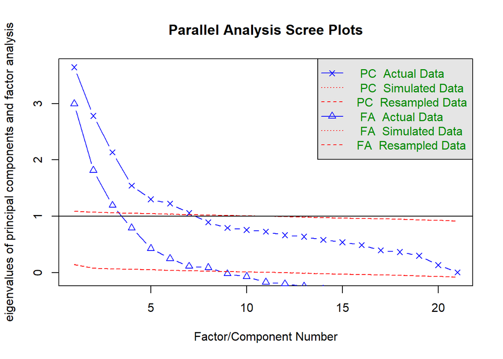

```
## Parallel analysis suggests that the number of factors =  8  and the number of components =  7
```

```r
fa.parallel(dating22, fa="both", n.iter=100)
```

```r
ev <- eigen(cor(dating22))
ev$values
```

```
##  [1] 3.646080534 2.783487735 2.133889152 1.545371111 1.303104265 1.225666848
##  [7] 1.058307000 0.893124464 0.795302348 0.760055543 0.727792695 0.666873598
## [13] 0.638928949 0.585083906 0.539249256 0.490091480 0.396517630 0.367757791
## [19] 0.300295559 0.136166369 0.006853765
```

Now, the maximum number of factors is 7. Another option is 3.

### Factor Analysis

Again, we try to use the maximum number of factors.

#### (1) No rotation, 7 factors

```r
fa1=fa(dating22, nfactors=7, rotate="none", fm="ml")
fa1
```

```
## Factor Analysis using method =  ml
## Call: fa(r = dating22, nfactors = 7, rotate = "none", fm = "ml")
## Standardized loadings (pattern matrix) based upon correlation matrix
##            ML6   ML1   ML7   ML5   ML2   ML3   ML4    h2     u2 com
## sports   -0.12  0.14 -0.07 -0.05 -0.06  0.00 -0.01 0.045 0.9554 3.2
## dining    0.39 -0.09  0.32  0.09  0.05  0.06  0.08 0.290 0.7095 2.4
## museums   0.91 -0.12 -0.11  0.14  0.02  0.01  0.03 0.880 0.1204 1.1
## art       0.88 -0.11 -0.10  0.13  0.00 -0.01  0.07 0.825 0.1746 1.1
## tv        0.08 -0.01  0.55  0.04 -0.01 -0.07  0.03 0.318 0.6821 1.1
## theater   0.56 -0.14  0.25  0.19  0.07  0.00  0.11 0.450 0.5499 2.0
## movies    0.35 -0.04  0.34  0.09  0.02 -0.02  0.05 0.255 0.7448 2.2
## concerts  0.40 -0.07  0.13  0.10 -0.04  0.02  0.07 0.204 0.7965 1.5
## shopping  0.28 -0.17  0.64  0.02  0.03  0.00  0.06 0.518 0.4821 1.6
## attr1_1  -0.13 -0.26 -0.09 -0.27 -0.18  0.05  0.00 0.200 0.7996 3.5
## amb1_1    0.14  0.10  0.31  0.14  0.09  0.00 -0.10 0.166 0.8340 2.6
## shar1_1   0.02  0.18 -0.02  0.38 -0.06 -0.17 -0.07 0.217 0.7834 2.0
## attr2_1   0.01 -0.95  0.00 -0.16 -0.22  0.01  0.15 0.995 0.0050 1.2
## sinc2_1   0.01  0.73  0.00 -0.14 -0.05 -0.62  0.22 0.995 0.0050 2.3
## intel2_1  0.00  0.70  0.00 -0.06 -0.12  0.61  0.34 0.995 0.0050 2.5
## fun2_1    0.00  0.01  0.00 -0.09  0.99  0.07 -0.05 0.995 0.0050 1.0
## amb2_1    0.02  0.54  0.00 -0.18 -0.28  0.14 -0.76 0.992 0.0079 2.3
## shar2_1  -0.03  0.31  0.01  0.92  0.02 -0.17 -0.07 0.973 0.0269 1.3
## attr3_1   0.10  0.03  0.19  0.06 -0.01  0.01  0.00 0.050 0.9501 1.8
## fun3_1    0.15  0.00  0.33 -0.04 -0.12  0.03  0.01 0.146 0.8544 1.8
## amb3_1    0.10  0.03  0.33 -0.01 -0.10  0.05 -0.05 0.138 0.8617 1.5
##
##                        ML6  ML1  ML7  ML5  ML2  ML3  ML4
## SS loadings           2.55 2.54 1.40 1.28 1.21 0.85 0.83
## Proportion Var        0.12 0.12 0.07 0.06 0.06 0.04 0.04
## Cumulative Var        0.12 0.24 0.31 0.37 0.43 0.47 0.51
## Proportion Explained  0.24 0.24 0.13 0.12 0.11 0.08 0.08
## Cumulative Proportion 0.24 0.48 0.61 0.73 0.84 0.92 1.00
##
## Mean item complexity =  1.9
## Test of the hypothesis that 7 factors are sufficient.
##
## df null model =  210  with the objective function =  9.72 with Chi Square =  79561.25
## df of  the model are 84  and the objective function was  1.51
##
## The root mean square of the residuals (RMSR) is  0.07
## The df corrected root mean square of the residuals is  0.11
##
## The harmonic n.obs is  8191 with the empirical chi square  17475.94  with prob <  0
## The total n.obs was  8191  with Likelihood Chi Square =  12347.83  with prob <  0
##
## Tucker Lewis Index of factoring reliability =  0.613
## RMSEA index =  0.134  and the 90 % confidence intervals are  0.132 0.136
## BIC =  11590.92
## Fit based upon off diagonal values = 0.87
## Measures of factor score adequacy
##                                                    ML6 ML1  ML7  ML5  ML2  ML3
## Correlation of (regression) scores with factors   0.96   1 0.84 0.99 1.00 1.00
## Multiple R square of scores with factors          0.93   1 0.70 0.98 1.00 0.99
## Minimum correlation of possible factor scores     0.86   1 0.40 0.96 0.99 0.99
##                                                    ML4
## Correlation of (regression) scores with factors   1.00
## Multiple R square of scores with factors          0.99
## Minimum correlation of possible factor scores     0.98
```

Higher Cumulative Var = 0.51 We have RMSR = 0.07 - the same - should be closer 0 Almost the same RMSEA index = 0.134 (<.08 acceptable, <.05 excellent) Tucker Lewis Index= 0.613 (>.90 acceptable, >.95 excellent) The result is better but still not good.

#### (2) No rotation, 3 factors

Now we will use 3 factors.

```r
fa2=fa(dating22, nfactors=3, rotate="none", fm="ml")
fa2
```

```
## Factor Analysis using method =  ml
## Call: fa(r = dating22, nfactors = 3, rotate = "none", fm = "ml")
## Standardized loadings (pattern matrix) based upon correlation matrix
##            ML3   ML2   ML1     h2     u2 com
## sports   -0.13  0.14  0.04 0.0378 0.9622 2.2
## dining    0.40 -0.10 -0.02 0.1710 0.8290 1.1
## museums   0.91 -0.09 -0.06 0.8390 0.1610 1.0
## art       0.90 -0.07 -0.07 0.8230 0.1770 1.0
## tv        0.08  0.00 -0.02 0.0064 0.9936 1.1
## theater   0.59 -0.14 -0.04 0.3713 0.6287 1.1
## movies    0.37 -0.04 -0.02 0.1360 0.8640 1.0
## concerts  0.42 -0.02 -0.08 0.1865 0.8135 1.1
## shopping  0.26 -0.16 -0.09 0.1026 0.8974 1.9
## attr1_1  -0.18 -0.14 -0.31 0.1494 0.8506 2.1
## amb1_1    0.16  0.05  0.15 0.0526 0.9474 2.2
## shar1_1   0.09  0.26  0.09 0.0859 0.9141 1.5
## attr2_1  -0.01 -0.61 -0.79 0.9951 0.0049 1.9
## sinc2_1  -0.02  0.57  0.36 0.4511 0.5489 1.7
## intel2_1 -0.01  0.52  0.32 0.3752 0.6248 1.7
## fun2_1    0.00 -0.63  0.77 0.9950 0.0050 1.9
## amb2_1   -0.07  0.59  0.21 0.3950 0.6050 1.3
## shar2_1   0.14  0.41  0.26 0.2571 0.7429 2.0
## attr3_1   0.11  0.04  0.01 0.0135 0.9865 1.3
## fun3_1    0.14  0.06 -0.09 0.0311 0.9689 2.1
## amb3_1    0.09  0.08 -0.05 0.0174 0.9826 2.5
##
##                        ML3  ML2  ML1
## SS loadings           2.69 2.08 1.72
## Proportion Var        0.13 0.10 0.08
## Cumulative Var        0.13 0.23 0.31
## Proportion Explained  0.41 0.32 0.27
## Cumulative Proportion 0.41 0.73 1.00
##
## Mean item complexity =  1.6
## Test of the hypothesis that 3 factors are sufficient.
##
## df null model =  210  with the objective function =  9.72 with Chi Square =  79561.25
## df of  the model are 150  and the objective function was  5.22
##
## The root mean square of the residuals (RMSR) is  0.11
## The df corrected root mean square of the residuals is  0.13
##
## The harmonic n.obs is  8191 with the empirical chi square  40924.11  with prob <  0
## The total n.obs was  8191  with Likelihood Chi Square =  42701.67  with prob <  0
##
## Tucker Lewis Index of factoring reliability =  0.249
## RMSEA index =  0.186  and the 90 % confidence intervals are  0.185 0.188
## BIC =  41350.05
## Fit based upon off diagonal values = 0.69
## Measures of factor score adequacy
##                                                    ML3  ML2  ML1
## Correlation of (regression) scores with factors   0.96 1.00 1.00
## Multiple R square of scores with factors          0.92 0.99 1.00
## Minimum correlation of possible factor scores     0.84 0.99 0.99
```

Lower Cumulative Var = 0.31 Worse RMSR = 0.11 (should be closer to 0) Worse RMSEA index = 0.186 (<.08 acceptable, <.05 excellent) Tucker Lewis Index= 0.249 (>.90 acceptable, >.95 excellent) The result is worse, *BUT* we need to look closer at the factor loadings

Factor Loadings of (1)

```r
print(fa1$loadings,cutoff = 0.4)
```

```
##
## Loadings:
##          ML6    ML1    ML7    ML5    ML2    ML3    ML4
## sports
## dining
## museums   0.913
## art       0.884
## tv                      0.552
## theater   0.559
## movies
## concerts  0.403
## shopping                0.638
## attr1_1
## amb1_1
## shar1_1
## attr2_1         -0.948
## sinc2_1          0.731                      -0.623
## intel2_1         0.703                       0.606
## fun2_1                                0.990
## amb2_1           0.538                             -0.759
## shar2_1                        0.918
## attr3_1
## fun3_1
## amb3_1
##
##                  ML6   ML1   ML7   ML5   ML2   ML3   ML4
## SS loadings    2.551 2.538 1.397 1.278 1.206 0.851 0.826
## Proportion Var 0.121 0.121 0.067 0.061 0.057 0.041 0.039
## Cumulative Var 0.121 0.242 0.309 0.370 0.427 0.468 0.507
```

Factor Loadings of (2)

```r
print(fa2$loadings,cutoff = 0.4)
```

```
##
## Loadings:
##          ML3    ML2    ML1
## sports
## dining
## museums   0.910
## art       0.901
## tv
## theater   0.592
## movies
## concerts  0.423
## shopping
## attr1_1
## amb1_1
## shar1_1
## attr2_1         -0.613 -0.787
## sinc2_1          0.569
## intel2_1         0.522
## fun2_1          -0.634  0.770
## amb2_1           0.588
## shar2_1          0.413
## attr3_1
## fun3_1
## amb3_1
##
##                  ML3   ML2   ML1
## SS loadings    2.691 2.080 1.721
## Proportion Var 0.128 0.099 0.082
## Cumulative Var 0.128 0.227 0.309
```

Firstly, both of them have variables that do not belong to neither of factors. Secondly, in the (1) there are factors to which only one variable belongs (ML5,ML2,ML4) and factors which by SS loadings should not be here (ML3,ML4), this is bad result. In the case (2) the situation with factors is better, but the cumulative variance is lower. So, it is very controversial what to change now.

At first, we will continue working on removing the variables.

### Exluding the variables 2.

```r
dating32 = select(dating22, -shopping,
                  -dining,
                  -movies,
                  -attr1_1,
                  -amb1_1,
                  -shar1_1,
                  -attr3_1,
                  -fun3_1,
                  -amb3_1)
```

### Comparison with different number of factors

Now we have more or less consistent set of variables, but the appropriate number of factors is still unknown. We will try different number of factors (from 3 to 7) with different rotation

```r
fac1=fa(dating32, nfactors=3, rotate="none", fm="ml")
fac1o=fa(dating32, nfactors=3, rotate="oblimin", fm="ml")
fac1v=fa(dating32, nfactors=3, rotate="varimax", fm="ml")

fac2=fa(dating32, nfactors=4, rotate="none", fm="ml")
fac2o=fa(dating32, nfactors=4, rotate="oblimin", fm="ml")
fac2v=fa(dating32, nfactors=4, rotate="varimax", fm="ml")

fac3=fa(dating32, nfactors=5, rotate="none", fm="ml")
fac3o=fa(dating32, nfactors=5, rotate="oblimin", fm="ml")
fac3v=fa(dating32, nfactors=5, rotate="varimax", fm="ml")

fac4=fa(dating32, nfactors=6, rotate="none", fm="ml")
fac4o=fa(dating32, nfactors=6, rotate="oblimin", fm="ml")
fac4v=fa(dating32, nfactors=6, rotate="varimax", fm="ml")

fac5=fa(dating32, nfactors=7, rotate="none", fm="ml")
fac5o=fa(dating32, nfactors=7, rotate="oblimin", fm="ml")
fac5v=fa(dating32, nfactors=7, rotate="varimax", fm="ml")
```

Comparison of main characteristics by number of factors Of course we cannot fully rely only on RMSEA, TLI and Cumulative Variance to tell how good is our factor analysis, but for now we try to meet the criteria as much as possible: RMSEA (<.08 acceptable, <.05 excellent) TLI (>.90 acceptable, >.95 excellent)

```r
rmsea1 = fac1$RMSEA
rmsea2 = fac2$RMSEA
rmsea3 = fac3$RMSEA
rmsea4 = fac4$RMSEA
rmsea5 = fac5$RMSEA

RMSEA = c(rmsea1[1], rmsea2[1], rmsea3[1], rmsea4[1], rmsea5[1])

TLI = c(fac1$TLI, fac2$TLI, fac3$TLI, fac4$TLI, fac5$TLI)

cumvar1 = fac1$Vaccounted
cumvar1 = cumvar1[3,3]
cumvar2 = fac2$Vaccounted
cumvar2 = cumvar2[3,4]
cumvar3 = fac3$Vaccounted
cumvar3 = cumvar3[3,5]
cumvar4 = fac4$Vaccounted
cumvar4 = cumvar4[3,6]
cumvar5 = fac5$Vaccounted
cumvar5 = cumvar5[3,7]

Cumulative_Var = c(cumvar1, cumvar2, cumvar3, cumvar4, cumvar5)

name = c("FA1 (3 factors)",
         "FA2 (4 factors)",
         "FA3 (5 factors)",
         "FA4 (6 factors)",
         "FA5 (7 factors)")

fa_comparison = data.frame(name,Cumulative_Var, TLI, RMSEA)
fa_comparison
```

```
##              name Cumulative_Var         TLI      RMSEA
## 1 FA1 (3 factors)      0.4758031  0.13005722 0.29669032
## 2 FA2 (4 factors)      0.5382459 -0.05394687 0.32655000
## 3 FA3 (5 factors)      0.5103276 -0.20815490 0.34961006
## 4 FA4 (6 factors)      0.6859750  0.80214235 0.14147548
## 5 FA5 (7 factors)      0.7522720  0.92288036 0.08832208
```

So, our choice is obviously FA5 with 7 factors. Choosing the rotation

### Rotation 2

#### No rotation

```r
print(fac5$loadings,cutoff = 0.4)
```

```
##
## Loadings:
##          ML1    ML2    ML7    ML3    ML6    ML4    ML5
## sports
## museums          0.425  0.645
## art              0.427  0.795
## tv
## theater          0.746         0.532
## concerts
## attr2_1  -0.957
## sinc2_1   0.686                             -0.537
## intel2_1  0.638                0.580               -0.439
## fun2_1                                0.969
## amb2_1    0.610                              0.591
## shar2_1   0.415  0.666        -0.422
##
##                  ML1   ML2   ML7   ML3   ML6   ML4   ML5
## SS loadings    2.479 1.713 1.109 1.106 1.058 0.796 0.765
## Proportion Var 0.207 0.143 0.092 0.092 0.088 0.066 0.064
## Cumulative Var 0.207 0.349 0.442 0.534 0.622 0.688 0.752
```

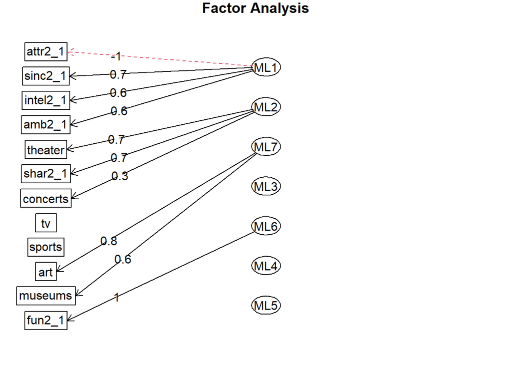

```r
fa.diagram(fac5)
```

#### Oblimin Rotation

```r
print(fac5o$loadings,cutoff = 0.4)
```

```
##
## Loadings:
##          ML7    ML1    ML2    ML5    ML4    ML3    ML6
## sports
## museums   0.827
## art       1.005
## tv
## theater                 0.993
## concerts
## attr2_1
## sinc2_1          1.030
## intel2_1                       1.026
## fun2_1                                              0.981
## amb2_1                                1.016
## shar2_1                                      1.019
##
##                  ML7   ML1   ML2   ML5   ML4   ML3   ML6
## SS loadings    1.782 1.222 1.208 1.179 1.175 1.146 1.086
## Proportion Var 0.148 0.102 0.101 0.098 0.098 0.095 0.090
## Cumulative Var 0.148 0.250 0.351 0.449 0.547 0.643 0.733
```

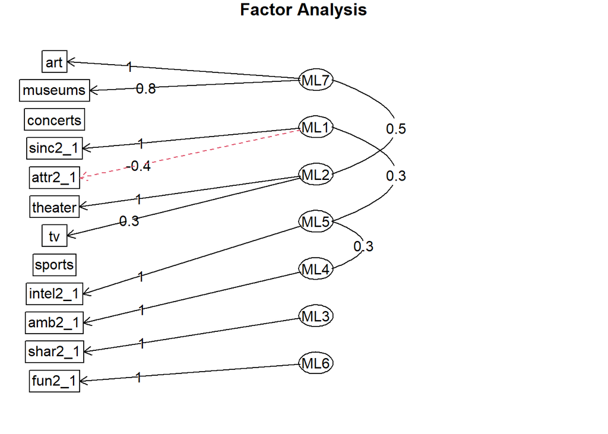

```r
fa.diagram(fac5o)
```

#### Varimax Rotation

```r
print(fac5v$loadings,cutoff = 0.4)
```

```
##
## Loadings:
##          ML7    ML1    ML3    ML4    ML5    ML6    ML2
## sports
## museums   0.858
## art       0.980
## tv
## theater   0.458                                     0.879
## concerts
## attr2_1         -0.541 -0.473 -0.459 -0.411
## sinc2_1          0.984
## intel2_1                0.978
## fun2_1                                       0.981
## amb2_1                         0.969
## shar2_1                               0.988
##
##                  ML7   ML1   ML3   ML4   ML5   ML6   ML2
## SS loadings    2.068 1.310 1.215 1.184 1.154 1.082 1.014
## Proportion Var 0.172 0.109 0.101 0.099 0.096 0.090 0.084
## Cumulative Var 0.172 0.282 0.383 0.481 0.578 0.668 0.752
```

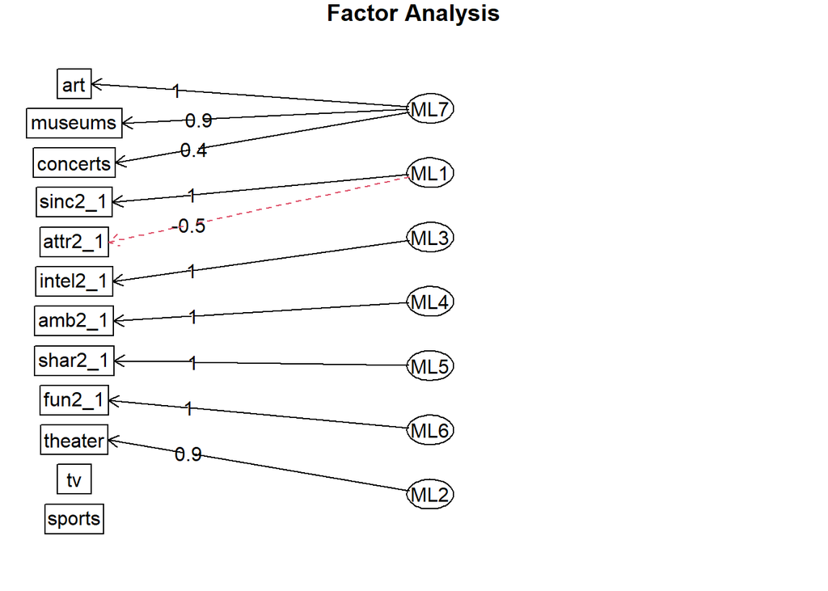

```r
fa.diagram(fac5v)
```

#### Conclusion

In Oblimin rotation, as well as in the Varimax rotation every latent factor describe something, but there is a big problem: most of the latent factors describe only one variable - so factors are not latent, they just describe the variable, it is not really explanatory. The no rotation option seems to be the best, however it has a problem there are some factors that do not describes anything, and there are some variables that do not belong to any factor. We need to fix it

### Final fix

In the final version it has been decided to stay with only 2 factors and 6 variables. It is not much, but it is the most precise option

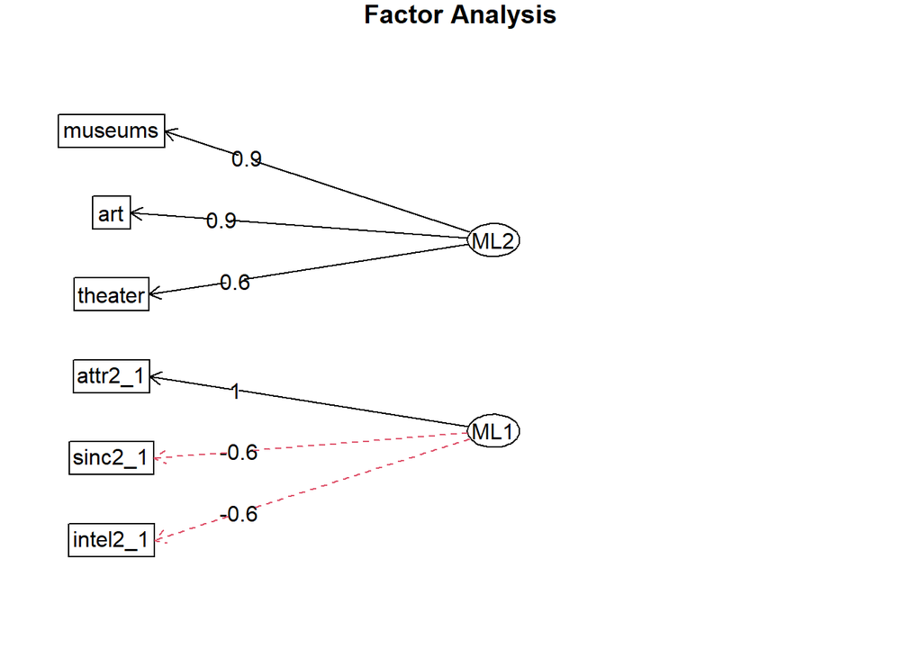

```r
fac5o_upgrade=fa(dating32[,-c(4,6,10,11,12,1)], nfactors=2, rotate="none", fm="ml")
fa.diagram(fac5o_upgrade)
```

```r
fac5o_upgrade
```

```
## Factor Analysis using method =  ml
## Call: fa(r = dating32[, -c(4, 6, 10, 11, 12, 1)], nfactors = 2, rotate = "none",
##     fm = "ml")
## Standardized loadings (pattern matrix) based upon correlation matrix
##            ML2   ML1   h2    u2 com
## museums   0.94  0.10 0.89 0.105 1.0
## art       0.90  0.11 0.81 0.187 1.0
## theater   0.55  0.12 0.32 0.683 1.1
## attr2_1  -0.01  1.00 1.00 0.005 1.0
## sinc2_1  -0.02 -0.63 0.40 0.599 1.0
## intel2_1 -0.01 -0.58 0.33 0.668 1.0
##
##                        ML2  ML1
## SS loadings           1.99 1.76
## Proportion Var        0.33 0.29
## Cumulative Var        0.33 0.63
## Proportion Explained  0.53 0.47
## Cumulative Proportion 0.53 1.00
##
## Mean item complexity =  1
## Test of the hypothesis that 2 factors are sufficient.
##
## df null model =  15  with the objective function =  2.63 with Chi Square =  21517.49
## df of  the model are 4  and the objective function was  0.06
##
## The root mean square of the residuals (RMSR) is  0.04
## The df corrected root mean square of the residuals is  0.07
##
## The harmonic n.obs is  8191 with the empirical chi square  330.42  with prob <  3e-70
## The total n.obs was  8191  with Likelihood Chi Square =  484.64  with prob <  1.4e-103
##
## Tucker Lewis Index of factoring reliability =  0.916
## RMSEA index =  0.121  and the 90 % confidence intervals are  0.112 0.13
## BIC =  448.6
## Fit based upon off diagonal values = 0.99
## Measures of factor score adequacy
##                                                    ML2  ML1
## Correlation of (regression) scores with factors   0.96 1.00
## Multiple R square of scores with factors          0.93 1.00
## Minimum correlation of possible factor scores     0.86 0.99
```

Also, we can see almost perfect complexity (min. 1.000118, max. 1.089190) ## Part 3. Description of factors

### Variables.

How interested are you in the following activities, on a scale of 1-10? 1. Art - art 2. Museum - museum 3. Theater -theater (related to ML2) All of the relations are positive

What do you think the opposite sex looks for in a date?

4. Attractive - attr2_1 (positive relation)
5. Sincere - sinc2_1 (negative relation)
6. Intelligent - intel2_1 (negative relation) (related to ML1)

### Factor names and description

#### ML1 - “Sexual desirability”

People look for different things in partners, different personality traits can attract a person. However, it is worth taking into account what kind of relationship a person wants: long-term for building a family, living together, or short-term to satisfy sexual needs.Since the goals during the search for a partner are different, the focus of attention will be aimed at different qualities of a person.

The authors (Pamela C. Regan, Lauren Levin,Susan Sprecher,F. Scott Christopher & Rodney Gate) of the research “What Characteristics Do Men and Women Desire In Their Short-Term Sexual and Long-Term Romantic Partners?” (2008) has such a results on this topic: “both men and women focused upon sexual desirability (e.g., attractiveness, health, sex drive, athleticism) when evaluating a short-term sexual partner, and placed more importance on similarity and on socially appealing personality characteristics (e.g., intelligence, honesty, warmth) when considering a long-term romantic relationship.”

So, as I think, the factor can be interpreted as Sexual desirability (or Sexuality) factor

#### ML2 - “Highbrowness”

ML2 describes the activities, which are strictly related to highbrow culture. In comparison with music or movies which can be highbrow, lowbrow or middlebrow, activities that this factor have a relation with is usually treated as highbrow. So, If a person says that he is fond of theater, art, or likes to go to museums, this signals that the person is fond of highbrow culture.

The terms of high- and lowbrow culture is one of the key concepts in the of Bourdie’s “The Difference: Social Criticism of the Judgment of Taste” (1979). “Taste has as much to do with expressed distaste for the aesthetic preferences attributed to other social groups as with positive adherence to the preferences of one’s own social group” and that is why such a distinction between cultural activites exists.

I would like to name the factor “Highbrowness”.